# Analysis of Longitunal Data

The final chapter of this course. This time we analyze longitunal data. The wranglng part consisted of taking dataset what was in wide-form (aka. single line for an observation, with time depended observation value as separate columns) and converted to long form where there are more observations (aka. lines) but with a time depended parameter. To achieve this one must separate the values that do not change between observations (aka. subject identifiers, group designators, etc.) from the time depended response variables.

The exercise uses to sets of data. Both are somewhat similar, with subject identifier and a group variable as factors that do not change between observations and columns with time in the columns names (weeks, WD) with the value of the response variable. These have been previously from this analysis been converted (in the data wrangling part) to longer form.

```r
# Read datasets from file and initialize required libraries
library(tidyr)
library(dplyr)
library(vtable)
```

```r
library(ggplot2)
library(lme4)
BPRSL <- read.csv("data/bprsl.csv")
RATSL <- read.csv("data/ratsl.csv")

# Factor the categories again, just in case
BPRSL$subject <- factor(BPRSL$subject)
BPRSL$treatment <- factor(BPRSL$treatment)
RATSL$ID <- factor(RATSL$ID)
RATSL$Group <- factor(RATSL$Group)

# and remove the X variables
BPRSL <- dplyr::select(BPRSL, -X)
RATSL <- dplyr::select(RATSL, -X)
```

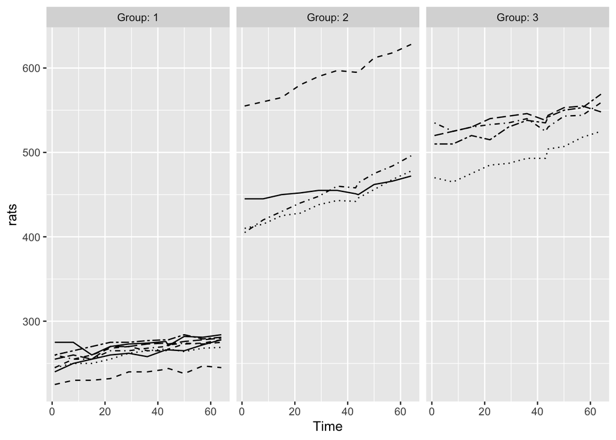

```r
ggplot(RATSL, aes(x = Time, y = rats, linetype = ID)) +
  geom_line() +
  scale_linetype_manual(values = rep(1:10, times=4)) +
  facet_grid(. ~ Group, labeller = label_both) +
  theme(legend.position = "none") +
  scale_y_continuous(limits = c(min(RATSL$rats), max(RATSL$rats)))
```

```r
# Number of Days
n <- RATSL$Time %>% unique() %>% length()

# Summary data with mean and standard error of RATS by Group and Time
RATSS <- RATSL %>%
  group_by(Group, Time) %>%
  summarise( mean = mean(rats), se = sd(rats) / sqrt(n) ) %>%
  ungroup()
```

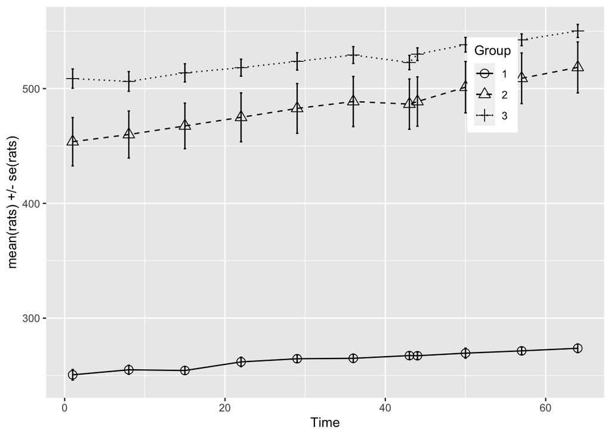

```r
# Plot the mean profiles
ggplot(RATSS, aes(x = Time, y = mean, linetype = Group, shape = Group)) +
  geom_line() +
  scale_linetype_manual(values = c(1,2,3)) +
  geom_point(size=3) +
  scale_shape_manual(values = c(1,2,3)) +
  geom_errorbar(aes(ymin=mean-se, ymax=mean+se, linetype="1"), width=0.3) +
  theme(legend.position = c(0.8,0.8)) +
  scale_y_continuous(name = "mean(rats) +/- se(rats)")
```

```r
RATSL8S <- RATSL %>%
  filter(Time > 0) %>%
  group_by(Group, ID) %>%
  summarise( mean=mean(rats) ) %>%
  ungroup()
```

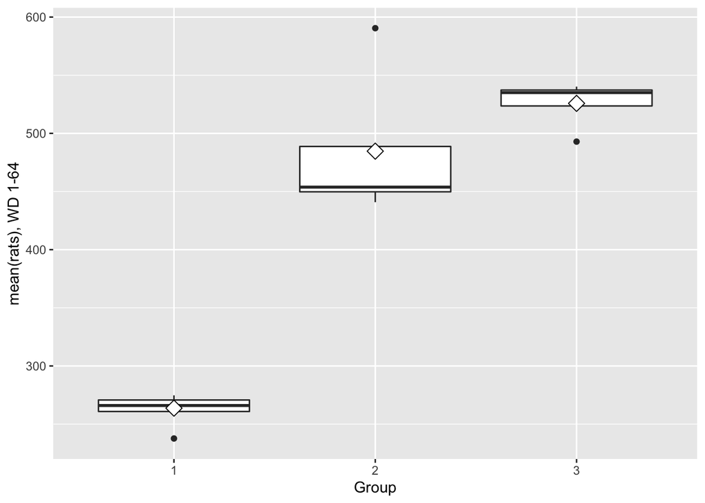

```r
ggplot(RATSL8S, aes(x = Group, y = mean)) +
  geom_boxplot() +
  stat_summary(fun.y = "mean", geom = "point", shape=23, size=4, fill = "white") +
  scale_y_continuous(name = "mean(rats), WD 1-64")
```

```r
# Compute analysis of variance to see if differences in groups are significant
aov <- aov(mean ~ Group, data = RATSL8S)
summary(aov)
```

```
##             Df Sum Sq Mean Sq F value   Pr(>F)
## Group        2 236732  118366   88.07 2.76e-08 ***
## Residuals   13  17471    1344
## ---
## Signif. codes:  0 '***' 0.001 '**' 0.01 '*' 0.05 '.' 0.1 ' ' 1
```

```r
# Use pairwise comparisons to see which groups differ significantly.
TukeyHSD(aov)
```

```
##   Tukey multiple comparisons of means
##     95% family-wise confidence level
##
## Fit: aov(formula = mean ~ Group, data = RATSL8S)
##
## $Group
##          diff       lwr      upr     p adj
## 2-1 220.98864 161.71195 280.2653 0.0000006
## 3-1 262.07955 202.80286 321.3562 0.0000001
## 3-2  41.09091 -27.35592 109.5377 0.2864426
```

While there are some outliers evident from the previous graphs, I decided to leave them, as the boxplots still suggest there might be a statistically significant difference between at least Group 1 and Group 2, as well as between Group 1 and Group 2. I further used anova to analyze the means between groups, which proves that there is a significant difference between Groups. To further distinguish between which groups the difference exists, I used Tukey multiple pairwise-comparisons. The p value for pairwise comparisons between Groups 2 and 1 as well as 3 and 1 are significant. This nicely supports what the graphical boxplots suggest. However although the confidence intervals for group 2 and 3 do not mostly cross in the previous graphs, they do not seem to differ significantly in pairwise-comparisons.

Next we use the BPRS dataset to do a linear mixed effects model.

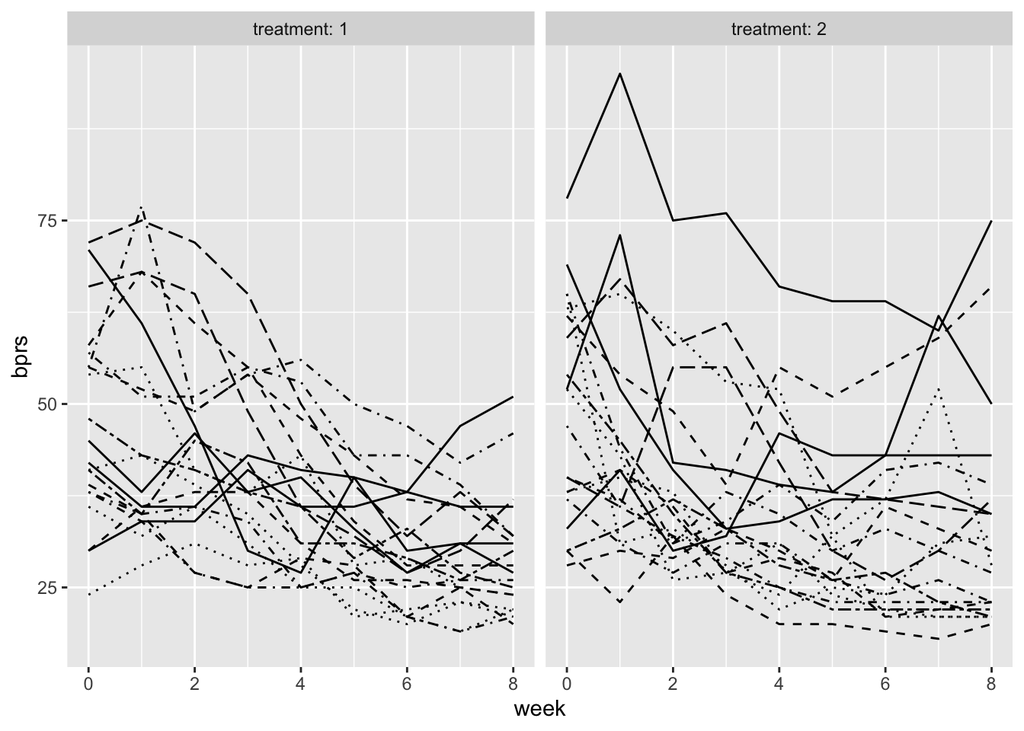

```r
ggplot(BPRSL, aes(x = week, y = bprs, linetype = subject)) +
  geom_line() +
  scale_linetype_manual(values = rep(1:10, times=4)) +
  facet_grid(. ~ treatment, labeller = label_both) +
  theme(legend.position = "none") +
  scale_y_continuous(limits = c(min(BPRSL$bprs), max(BPRSL$bprs)))
```

There does not seem to be a significant difference between the treatment groups. Let try to create a regression model.

```r
BPRS_reg <- lm(bprs ~ week + treatment, data = BPRSL)

# print out a summary of the model
summary(BPRS_reg)
```

```
##
## Call:
## lm(formula = bprs ~ week + treatment, data = BPRSL)
##
## Residuals:
##     Min      1Q  Median      3Q     Max
## -22.454  -8.965  -3.196   7.002  50.244
##
## Coefficients:
##             Estimate Std. Error t value Pr(>|t|)
## (Intercept)  46.4539     1.3670  33.982   <2e-16 ***
## week         -2.2704     0.2524  -8.995   <2e-16 ***
## treatment2    0.5722     1.3034   0.439    0.661
## ---
## Signif. codes:  0 '***' 0.001 '**' 0.01 '*' 0.05 '.' 0.1 ' ' 1
##
## Residual standard error: 12.37 on 357 degrees of freedom
## Multiple R-squared:  0.1851, Adjusted R-squared:  0.1806
## F-statistic: 40.55 on 2 and 357 DF,  p-value: < 2.2e-16
```

Treament group does not seem to be a significant explanatory variable, however weeks is significant.

```r
BPRS_ref <- lmer(bprs ~ week + treatment + (1 | subject), data = BPRSL, REML = FALSE)
BPRS_ref1 <- lmer(bprs ~ week + treatment + (week | subject), data = BPRSL, REML = FALSE)
anova(BPRS_ref1, BPRS_ref)
```

```
## Data: BPRSL
## Models:
## BPRS_ref: bprs ~ week + treatment + (1 | subject)
## BPRS_ref1: bprs ~ week + treatment + (week | subject)
##           npar    AIC    BIC  logLik deviance  Chisq Df Pr(>Chisq)
## BPRS_ref     5 2748.7 2768.1 -1369.4   2738.7
## BPRS_ref1    7 2745.4 2772.6 -1365.7   2731.4 7.2721  2    0.02636 *
## ---
## Signif. codes:  0 '***' 0.001 '**' 0.01 '*' 0.05 '.' 0.1 ' ' 1
```

We see that with week the intercept model is slightly better (Chi-Square p of 0.02636). Now we create model that combines treatment with time (weeks) and compare that with the model that has just time (weeks) previously.

```r
BPRS_ref2 <- lmer(bprs ~ week * treatment + (week | subject), data = BPRSL, REML = FALSE)
anova(BPRS_ref2, BPRS_ref1)
```

```
## Data: BPRSL
## Models:
## BPRS_ref1: bprs ~ week + treatment + (week | subject)
## BPRS_ref2: bprs ~ week * treatment + (week | subject)
##           npar    AIC    BIC  logLik deviance  Chisq Df Pr(>Chisq)
## BPRS_ref1    7 2745.4 2772.6 -1365.7   2731.4
## BPRS_ref2    8 2744.3 2775.4 -1364.1   2728.3 3.1712  1    0.07495 .
## ---
## Signif. codes:  0 '***' 0.001 '**' 0.01 '*' 0.05 '.' 0.1 ' ' 1
```

It would seem that this model is not significantly better that the model with just time. This would seem to match with our previous assumptions from the graphs that the treatment does not have a significant difference in the bprs scores.

Finally lets try to create a version with fitted values and draw a graphs representing them.

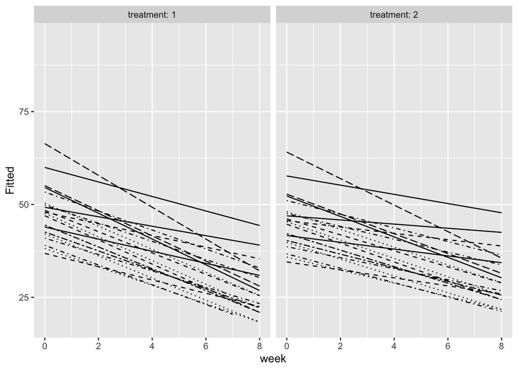

```r
Fitted <- fitted(BPRS_ref2)
BPRSL <- BPRSL %>% mutate(Fitted)

ggplot(BPRSL, aes(x = week, y = Fitted, linetype = subject)) +
  geom_line() +
  scale_linetype_manual(values = rep(1:10, times=4)) +
  facet_grid(. ~ treatment, labeller = label_both) +
  theme(legend.position = "none") +
  scale_y_continuous(limits = c(min(BPRSL$bprs), max(BPRSL$bprs)))
```